# American-returned students in 東方雜誌

Authorship Analysis

Cécile Armand

2025-03-08

Abstract

This document provides the code for exploring how and by whom the American-returned students were discussed in the Chinese periodical *Dongfang zazhi* 東方雜誌 (Eastern Miscellany) from 1905 to 1948.

# Introduction

This document is part of a series dedicated to a corpus-based analysis of articles on Japan- and U.S.-returned students in *Dongfang zazhi* 東方雜誌 (*The Eastern Miscellany*). Building on a [previous script](https://bookdown.enpchina.eu/dfzz_liuxue/liumei_corpus.html) aimed at constructing and exploring a corpus focused on American-returned students, this document provides code for extracting and analyzing biographical information about the authors of these articles.

# Authorship Information

## Extraction/Curation

```r
# clean authors' names

library(dplyr)
library(tidyr)

liumei_authors <- liumei_clean %>% select(DocId, authors) %>%
  mutate(Author = str_replace_all(authors, "\\[", "")) %>%
  mutate(Author = str_replace_all(Author, "\\]", ""))%>%
  mutate(Author = str_replace_all(Author, "\\'", "")) %>%
  separate_rows(Author, sep = ",\\s*")
```

```r
liumei_authors
```

| DocId | authors | Author |
| --- | --- | --- |
| 1905-2-1-66 | NA | NA |
| 1905-2-11-27 | NA | NA |
| 1905-2-2-37 | NA | NA |
| 1906-3-4-39 | NA | NA |
| 1906-3-8-55 | NA | NA |
| 1907-4-11-20 | NA | NA |
| 1907-4-12-53 | NA | NA |
| 1907-4-7-38 | NA | NA |
| 1908-5-1-9 | NA | NA |
| 1909-6-9-65 | NA | NA |

[output cut: 137 more lines]

## Basic statistics

```r
liumei_authors %>% group_by(Author) %>% count(sort = TRUE) # number of articles by author
liumei_authors %>% group_by(DocId) %>% count(sort = TRUE) # co-authored articles
```

# Biographical Information

We searched for biographical information on the authors in Chinese Wikipedia and the Who’s Who publications provided by the Institute of Modern History (IMH), Academia Sinica, Taipei.

```r
# Create a function for multiple queries

multiple_search <- function(queries, corpus) {
  results <- histtext::search_documents_ex(queries[1], corpus) %>%
    mutate(Q=queries[1])
  for(q in queries){
    new_result <- histtext::search_documents_ex(q, corpus) %>%
      mutate(Q=q)
    results <- dplyr::bind_rows(results, new_result)
  }
  distinct(results)
}

# Create the list of names to query

liumei_authors_list <- liumei_authors %>% drop_na(Author) %>% mutate(Queries=str_glue('"{Author}"'))
```

## Wikipedia

```r
library(histtext)

liumei_authors_wiki <- multiple_search(liumei_authors_list$Queries, "wikibio-zh") # 957 results
liumei_authors_wiki <- liumei_authors_wiki %>% group_by(Q)

# Eliminate irrelevant results

liumei_list_names <- liumei_authors_list$Author
liumei_list_names <-  paste(liumei_list_names, sep = "", collapse = "|")
liumei_authors_wiki <- liumei_authors_wiki %>% mutate(title_match = str_extract(Title, liumei_list_names))
liumei_authors_wiki <- liumei_authors_wiki %>% group_by(title_match) %>% add_tally()

liumei_authors_wiki_match <- liumei_authors_wiki %>% filter(!is.na(title_match)) # 23 matches

# 23 bios remain
```

```r
liumei_authors_wiki_match
```

| DocId | Date | Title | Source | Q | title_match | n |
| --- | --- | --- | --- | --- | --- | --- |
| 1624658 | 2020/06/01 | 周厚坤 | wikibio | "周厚坤" | 周厚坤 | 1 |
| 3504845 | 2020/06/01 | 王毓祥 | wikibio | "王毓祥" | 王毓祥 | 1 |
| 6500 | 2020/06/01 | 胡適 | wikibio | "胡適" | 胡適 | 5 |
| 6279211 | 2020/06/01 | 胡適日記 | wikibio | "胡適" | 胡適 | 5 |
| 39373 | 2020/06/01 | 羅家倫 | wikibio | "胡適" | 羅家倫 | 2 |
| 20761 | 2020/06/01 | 蔡元培 | wikibio | "胡適" | 蔡元培 | 2 |
| 3323451 | 2020/06/01 | 徐寶謙 | wikibio | "徐寶謙" | 徐寶謙 | 1 |
| 39373 | 2020/06/01 | 羅家倫 | wikibio | "羅家倫" | 羅家倫 | 2 |
| 6500 | 2020/06/01 | 胡適 | wikibio | "羅家倫" | 胡適 | 5 |
| 2820950 | 2020/06/01 | 潘公展 | wikibio | "潘公展" | 潘公展 | 1 |

[output cut: 13 more lines]

```r
# Extract the full text of biographies

liumei_authors_wiki_ft <- histtext::get_documents(liumei_authors_wiki_match, "wikibio-zh")
```

```r
liumei_authors_wiki_ft
```

| DocId | Date | Title | Source | Text |
| --- | --- | --- | --- | --- |
| 1624658 | 2020/06/01 | 周厚坤 | wikibio | \n周厚坤（1889年－20世纪？），字朋西，江苏无锡人，中文打字机之父，也是美国首位航空工程硕士毕业生。夏偕复之婿[1]。\n周厚坤于1900年起先后就读于南洋公学（附属小学、附属中学、电机科）[2]、唐山路矿学堂[3]。1910年作为第二批庚子赔款留美生前往美国留学，就读于麻省理工学院，先后学习机械工程、造船工程。期间于1912年发明了第一台中文打字机。[4][5]1914年获学士学位。后又就… |
| 3504845 | 2020/06/01 | 王毓祥 | wikibio | \n參數所指定的目標頁面不存在，建議更正成存在頁面或直接建立下列一個頁面（建立前請先搜尋是否有合適的存在頁面可以取代）：\n王毓祥（1886年－1949年）字祉伟，湖南衡阳人。中华民国教育家，上海大夏大学创办人之一，大夏大学校歌的词作者。[1]\n王毓祥生于一个地方望族，家学深厚。中年时，王毓祥赴美国留学，先后在加利福尼亚大学、芝加哥大学、纽约大学等校研修经济学。归国后，历任国立东南大学、暨南大学… |
| 6500 | 2020/06/01 | 胡適 | wikibio | \n胡適[註 1]（1891年12月17日－1962年2月24日），原名嗣穈，行名洪骍，字希彊[註 2][1]，后改名適，字適之，笔名天风、臧晖、铁儿等[註 3][2]。中華民國作家，安徽绩溪上庄村人（生于上海浦东川沙），因提倡文学革命而成为新文化运动的领袖之一，曾担任国立北京大学校长、中央研究院院長、中华民国驻美大使、私立南开大学校董会董事等職。胡适興趣廣泛，著述豐富，在文学、哲学、史学、考据学… |
| 6279211 | 2020/06/01 | 胡適日記 | wikibio | \n《胡適日記》是胡適自1910年开始记日记，直到1962年去世之前，前後逾50年，總字數達400萬餘言。\n胡適早年的日記都是流水帳。1911年6月，胡適開始打牌，日記常見“打牌”。可能是打牌耽误了胡适的功課，遂决心戒牌，該年9月6日胡適在日记提及：“昨日，与金涛君相戒不复打牌”，遂不見打牌的記載。《胡適日記全集》中還保存有反對他，甚至詆毀他的文章和剪報，這是名人留世日記少見的風格。對此何炳棣頗… |
| 39373 | 2020/06/01 | 羅家倫 | wikibio | \n罗家伦（1897年12月21日－1969年12月25日），字志希，籍貫浙江绍兴，生于江西进贤，中国教育家、历史学家，“五四运动”的命名者。\n1897年12月21日生。少承庭训，习读文史，后曾就读于南昌英文夜校、上海复旦公学。1917年以作文滿分考入國立北京大学文科[2]，期间與傅斯年等創刊《新潮》月刊，協助胡適、錢玄同等文學改革運動。[1]1919年五四運動中，撰写《北京學界全體宣言》，为学… |
| 20761 | 2020/06/01 | 蔡元培 | wikibio | \n蔡元培（1868年1月11日－1940年3月5日），字仲申，又字鶴卿、民友、孑民，號寉庼，小名宜哥，小字意可，乳名阿培[3]，並曾化名蔡振、周子餘，浙江绍兴山陰縣（今浙江紹興）人，原籍浙江诸暨，25岁成进士，被点翰林院庶吉士。近代革命家、教育家、政治家，也是中国近代民族学研究的先驱[4]。\n蔡元培是中華民國首任教育總長，1916年—1927年任北京大学校长[5]，革新北大，開「學術」與「自由… |
| 3323451 | 2020/06/01 | 徐寶謙 | wikibio | \n徐寶謙，浙江省嘉興府石門縣人，清朝政治人物、同進士出身。\n光緒六年（1880年），参加庚辰科殿試，登進士三甲第83名。同年五月，授刑部主事[1]。\n |
| 39373 | 2020/06/01 | 羅家倫 | wikibio | \n罗家伦（1897年12月21日－1969年12月25日），字志希，籍貫浙江绍兴，生于江西进贤，中国教育家、历史学家，“五四运动”的命名者。\n1897年12月21日生。少承庭训，习读文史，后曾就读于南昌英文夜校、上海复旦公学。1917年以作文滿分考入國立北京大学文科[2]，期间與傅斯年等創刊《新潮》月刊，協助胡適、錢玄同等文學改革運動。[1]1919年五四運動中，撰写《北京學界全體宣言》，为学… |
| 6500 | 2020/06/01 | 胡適 | wikibio | \n胡適[註 1]（1891年12月17日－1962年2月24日），原名嗣穈，行名洪骍，字希彊[註 2][1]，后改名適，字適之，笔名天风、臧晖、铁儿等[註 3][2]。中華民國作家，安徽绩溪上庄村人（生于上海浦东川沙），因提倡文学革命而成为新文化运动的领袖之一，曾担任国立北京大学校长、中央研究院院長、中华民国驻美大使、私立南开大学校董会董事等職。胡适興趣廣泛，著述豐富，在文学、哲学、史学、考据学… |
| 2820950 | 2020/06/01 | 潘公展 | wikibio | \n潘公展（1895年10月23日－1975年6月23日），旧名有猷，号淦清、幹卿，男，浙江吴兴人，中華民国记者、政治人物，中国国民党文化、宣传方面的干将，CC派要人。\n潘公展生于一个絹商家庭。入湖州两等小学堂后，他秘密加入革命派团体。1912年（民国元年），他入上海圣约翰大学外語系。在校期间，他是《時事新報》的《学灯》副刊以及《国民日報》的《覚悟》副刊的特约撰稿人。此外，他还参加了柳亚子的南社… |

[output cut: 13 more lines]

## Who’s Who (IMH collection)

```r
library(histtext)

liumei_authors_imh <- multiple_search(liumei_authors_list$Queries, "imh-zh") # 202 results

liumei_authors_imh <- liumei_authors_imh %>% mutate(title_match = str_extract(Title, liumei_list_names))
liumei_authors_imh <- liumei_authors_imh %>% group_by(title_match) %>% add_tally()

# Eliminate irrelevant results

liumei_authors_imh_match <- liumei_authors_imh %>% filter(!is.na(title_match)) #  108 results remain

liumei_authors_imh_match <- liumei_authors_imh_match %>% distinct(DocId, Title) %>%
  mutate(Title_clean = str_replace(Title, "【", ""))  %>%
  mutate(Title_clean = str_replace(Title_clean, "】", "")) %>%
  mutate(Title_clean = str_extract(Title_clean, "^.{3}")) %>% relocate(title_match, .after = Title_clean)

liumei_authors_imh_match <- liumei_authors_imh_match %>% filter(!DocId == "imh-72-629")

liumei_authors_imh_match <- liumei_authors_imh_match %>% mutate(title_length = nchar(Title)) %>% mutate(title_length2 = nchar(Title_clean)) %>%
  mutate(query_length = nchar(title_match)) %>% mutate(dif = (query_length-title_length))  %>% mutate(dif2 = (query_length-title_length2))

liumei_authors_imh_filtered <- liumei_authors_imh_match %>% filter(!dif2 == "-1") # 77 bios remain

liumei_authors_imh_unique <- liumei_authors_imh_filtered %>%
  select(DocId, title_match) %>% rename(Name = title_match) %>%
  group_by(Name) %>% count() # 28 unique authors remain, from 1 to 7 biographies each

liumei_authors_imh_filtered <- liumei_authors_imh_filtered %>% select(DocId, title_match) %>% rename(Name = title_match)
liumei_authors_imh_filtered <- liumei_authors_imh_filtered %>%
  group_by(Name) %>% add_tally()

# 77 biographies referring to 28 unique names remain, from 1 to 7 bios per author
```

```r
liumei_authors_imh_filtered
```

| DocId | Name | n |
| --- | --- | --- |
| imh-45-1254 | 周厚坤 | 2 |
| imh-11-94 | 周厚坤 | 2 |
| imh-14-252 | 王毓祥 | 1 |
| imh-05-18504 | 陸費執 | 1 |
| imh-05-8482 | 周由廑 | 1 |
| imh-51-3152 | 莊澤宣 | 3 |
| imh-47-2947 | 莊澤宣 | 3 |
| imh-14-2391 | 莊澤宣 | 3 |
| imh-05-13746 | 徐寶謙 | 2 |
| imh-14-1699 | 徐寶謙 | 2 |

[output cut: 67 more lines]

```r
# Retrieve full text

liumei_authors_imh_ft <- histtext::get_documents(liumei_authors_imh_filtered, "imh-zh")
```

```r
liumei_authors_imh_ft
```

| DocId | Date | Title | Source | Text |
| --- | --- | --- | --- | --- |
| imh-45-1254 | 1918 | 周厚坤 | 清末民初中國官紳人名錄 | 周厚坤\n厚坤\nChou Hou-k'un\n江蘇省無錫\n |
| imh-11-94 | 1917 | 周厚坤 字厚坤。年二十八 | 游美同學錄 | 54周厚坤 字厚坤。年二十八歲。生於江蘇無錫。永久\n通信處。上海南洋公學。未婚。初畢業上海南洋公學。又學\n於唐山路礦學校。宣統二年。以官費游美。入伊里諾愛大\n學。習土木工程。宣統三年。入麻省工業學校。習機器工\n程。兼造船科。民國三年。得學士學位。習航空工程。民國\n四年。得碩士學位。曾得美國航空學會之奬。爲留美學生\n會書記。撰航空機振動促進法。載航空世紀報。發明漢文\n打字機。在美國中國… |
| imh-14-252 | 1931 | 王毓祥 | 當代中國名人錄 | 王毓祥\n字祉偉。\n湖南衡陽人。\n美國紐約大學碩士。\n歷任國立東南大學商科、吳淞中國公學商科及國立曁南學校商科教授、廈門大學商科主任、全國電政總局科長。現任上海大夏大學秘書兼校務發展委員會主席、交通部電信學校校長。\n |
| imh-05-18504 | 1941 | 陸費執 | 上海人名錄 | 陸費執\n叔辰\n理事兼編輯\n河南路福州路口中華書局 電話：九一一六○ |
| imh-05-8482 | 1941 | 周由廑 | 上海人名錄 | 周由廑\n西摩路八一五弄六號 電話：三七六七八 |
| imh-51-3152 | 1940 | 莊澤宣 | 中國文化界人物總鑑 | 莊澤宣\n浙江嘉興\n1896-X\n |
| imh-47-2947 | 1928 | 莊澤宣 | 現代支那人名鑑 | 莊澤宣\nChuang Tsê-hsüan\n廣東省\n廣東 |
| imh-14-2391 | 1931 | 莊澤宣 | 當代中國名人錄 | 莊澤宣\n年三十六歲。\n浙江嘉興人。\n美國哥倫比亞大學哲學博士。\n歷任北京淸華學校及廈門大學心理學教授。現任廣州國立中山大學教育研究所主任。著有教育概論、西洋教育制度之演進及其背景等書。\n |
| imh-05-13746 | 1941 | 徐寶謙 | 上海人名錄 | 徐寶謙\n敎授\n圓明園路二○九號滬江大學 電話：一八三二○ |
| imh-14-1699 | 1931 | 徐寶謙 | 當代中國名人錄 | 徐寶謙\n美國碩士。\n現任北平燕京大學哲學系主任兼教授。\n |

[output cut: 67 more lines]

## Biographical Attributes

```r
## Bind the two datasets

liumei_authors_bio <- bind_rows(liumei_authors_imh_ft, liumei_authors_wiki_ft)
```

### Year of Birth

```r
# Retrieve year of birth

liumei_authors_bio$year <- regmatches(liumei_authors_bio$Text, gregexpr("\\d{4}", liumei_authors_bio$Text))
liumei_authors_bio$birth <- regmatches(liumei_authors_bio$year, regexpr("[[:digit:]]+", liumei_authors_bio$year))
liumei_authors_bio$year <- NULL
liumei_authors_bio_filtered <- liumei_authors_bio %>% filter(birth < 1948) %>% filter(birth > 1800) # 46 bios remain
```

```r
liumei_authors_bio_filtered
```

[output not shown]

[output cut: 36 more lines]

### Native Place

```r
# Retrieve native provinces based on list

library(readr)
provinces <- read_delim("~/indexes/provinces.csv",
                       delim = ";", escape_double = FALSE, trim_ws = TRUE)

provinces <- provinces %>% na.omit()

# create vector

prov_list <- provinces$Province
prov_list <-  paste(prov_list, sep = "", collapse = "|")
liumei_authors_bio_filtered <- liumei_authors_bio_filtered %>% mutate(birthplace = str_extract(Text, prov_list))
```

### Education

```r
# Retrieve academic disciplines based on typology

# Load typology

library(readr)
disciplines <- read_delim("~/indexes/disciplines.csv",
                                    delim = ";", escape_double = FALSE, trim_ws = TRUE)

# create vector

disc_list <- disciplines$Level2__ZhT_MCBD
disc_vec <-  paste(disc_list, sep = "", collapse = "|")

liumei_authors_bio_filtered <- liumei_authors_bio_filtered %>%
  mutate(discipline = str_extract_all(Text, disc_vec)) %>%
  mutate(discipline = as.character(discipline))
```

```r
# identify those who studied or traveled to foreign countries

liumei_authors_bio_filtered <- liumei_authors_bio_filtered %>%
  mutate(edu_country = str_extract_all(Text, "留美|留日|留法|留德|留英")) %>%
  mutate(edu_country = as.character(edu_country)) %>%
  mutate(country = str_extract_all(Text, "美國|日本|法國|德國|英國")) %>%
  mutate(country = as.character(country))
```

```r
liumei_authors_bio_filtered
```

| DocId | Date | Title | Source | Text | birth | birthplace | discipline | edu_country | country |
| --- | --- | --- | --- | --- | --- | --- | --- | --- | --- |
| imh-51-3152 | 1940 | 莊澤宣 | 中國文化界人物總鑑 | 莊澤宣\n浙江嘉興\n1896-X\n | 1896 | 浙江 | character(0) | character(0) | character(0) |
| imh-51-1478 | 1940 | 祁森煥 | 中國文化界人物總鑑 | 祁森煥\n祁森煥\n伯文\n河北北京\n1899-X\n | 1899 | 河北 | character(0) | character(0) | character(0) |
| imh-54-268 | 1942 | 祁森煥 | 日本留學支那要人錄 | 祁森煥\n祁森煥\n伯文\n河北省北京\n1899\n | 1899 | 河北 | character(0) | character(0) | character(0) |
| imh-51-4894 | 1940 | 羅家倫 | 中國文化界人物總鑑 | 羅家倫\n志希\n浙江紹興\n1895-X\n | 1895 | 浙江 | character(0) | character(0) | character(0) |
| imh-72-1933 | UNK | 羅家倫 | 外交檔案人物 | 羅家倫\n、(字)志希\n\n■學經歷時間職務出處備註 北京大學 中華民國外交史辭典, p.392 民國36.2.28(1947.02.28) [印度]特命全權大使 中國駐外各公大使館歷任館長銜名年表（增訂本）, p.4 民國37年(1948) [印度]特命全權大使 中國駐外各公大使館歷任館長銜名年表（增訂本）, p.4 民國38年(1949) [印度]特命全權大使 中國駐外各公大使館歷任館長銜名… | 1947 | 浙江 | c("外交", "外交", "外交") | character(0) | character(0) |
| imh-51-4303 | 1940 | 潘公展 | 中國文化界人物總鑑 | 潘公展\n浙江吳興\n1895-X\n | 1895 | 浙江 | character(0) | character(0) | character(0) |
| imh-53-323 | 1941 | 潘公展 | 最新支那要人傳 | 潘公展\nPan Kung-chan\n浙江省吳興縣\n1895\n | 1895 | 浙江 | character(0) | character(0) | character(0) |
| imh-03-1576 | 1936 | 潘公展 | 上海工商人名錄 | 潘公展\n年四十二歲（公曆1895年生）。\n浙江吳興人。\n聖約翰大學畢業。\n曾任上海市社會局局長、中國公學副校長、晨報社股份有限公司董事兼總經理。現為上海市教育局局長、上海特別市黨部常務委員、中國國民黨中央執行委員兼中央文化事業委員會委員、兒童書局董事長。\n | 1895 | 浙江 | c("社會", "公學", "教育") | character(0) | character(0) |
| imh-54-446 | 1942 | 高一涵 | 日本留學支那要人錄 | 高一涵\n象山\n安徽省六安\n1885\n | 1885 | 安徽 | character(0) | character(0) | character(0) |
| imh-51-2020 | 1940 | 高一涵 | 中國文化界人物總鑑 | 高一涵\n涵廬、象山\n安徽六安\n1885-X\n | 1885 | 安徽 | character(0) | character(0) | character(0) |

[output cut: 36 more lines]

## Named Entity Recognition (NER)

In the following section, we extract named entities from biographies using [models specifically developed by the ENP-China team](https://bookdown.enpchina.eu/HistText_Book/named-entity-recognition-ner.html) for modern Chinese historical texts, integrated into the HistText package.

### Extraction

```r
liumei_authors_imh_ner <- ner_on_corpus(liumei_authors_imh_ft, corpus = "imh-zh")
liumei_authors_wiki_ner <- ner_on_corpus(liumei_authors_wiki_ft, corpus = "wikibio-zh")
liumei_authors_ner <- bind_rows(liumei_authors_imh_ner, liumei_authors_wiki_ner) # bind the two lists
```

```r
liumei_authors_ner
```

| DocId | Type | Text | Start | End | Confidence |
| --- | --- | --- | --- | --- | --- |
| imh-45-1254 | PERSON | 周厚 | 0 | 2 | -1 |
| imh-45-1254 | PERSON | 坤 | 2 | 3 | -1 |
| imh-45-1254 | PERSON | 厚坤 | 4 | 6 | -1 |
| imh-45-1254 | GPE | 江蘇省 | 21 | 24 | -1 |
| imh-45-1254 | GPE | 無錫 | 24 | 26 | -1 |
| imh-11-94 | CARDINAL | 54 | 3 | 5 | -1 |
| imh-11-94 | PERSON | 周厚 | 9 | 11 | -1 |
| imh-11-94 | PERSON | 坤 | 11 | 12 | -1 |
| imh-11-94 | PERSON | 字厚坤 | 13 | 16 | -1 |
| imh-11-94 | DATE | 二十八歲 | 18 | 22 | -1 |

[output cut: 9990 more lines]

In the following section, we focus on organizations to define occupational profiles, but we could also examine other types of entities, such as events in which they were involved or creative works they produced during their careers.

### Curation

```r
# Filter organizations

liumei_authors_org <- liumei_authors_ner %>% filter(Type == "ORG")

# Preliminary cleaning

liumei_authors_org <- liumei_authors_org %>%
  mutate(text_clean = str_replace(Text, "《", "")) %>%
  mutate(text_clean = str_replace(text_clean, ">", "")) %>%
  relocate(text_clean, .after = Text) %>%
  mutate(text_clean, text_clean=str_replace(text_clean,"（.*","")) %>%
  mutate(text_clean, text_clean=str_replace(text_clean,"\\(.*","")) %>%
  mutate(text_clean, text_clean=str_replace(text_clean,"\\(.*",""))%>%
  mutate(text_clean = str_replace(text_clean, " ", "")) %>%
  mutate(text_clean = str_replace(text_clean, " ", ""))%>%
  mutate(length = nchar(text_clean)) %>%
  relocate(length, .after = text_clean)

liumei_authors_org <- liumei_authors_org %>% filter(length > 1) # 1370

# Extract suffixes and prefixes to help classify and locate institutions

liumei_authors_org <- liumei_authors_org %>%
  mutate(class = str_sub(text_clean,-2,-1)) %>%
  relocate(class, .after = text_clean)

liumei_authors_org <- liumei_authors_org %>%
  mutate(pre = str_sub(text_clean, 1, 2)) %>%
  relocate(pre, .before = text_clean)

# Remove residual noise (position verbs, etc)

liumei_authors_org <- liumei_authors_org %>%
  mutate(text_clean = str_replace(text_clean, "任", ""))%>%
  mutate(text_clean = str_replace(text_clean, "入", ""))%>%
  mutate(text_clean = str_replace(text_clean, "久", ""))%>%
  mutate(text_clean = str_replace(text_clean, "于", ""))%>%
  mutate(text_clean = str_replace(text_clean, "於", ""))%>%
  mutate(text_clean =  str_replace(text_clean, "從", "")) %>%
  mutate(length = nchar(text_clean)) %>%
  filter(length > 1) %>% #
  mutate(pre = str_sub(text_clean, 1, 2))

liumei_authors_org <- liumei_authors_org %>%
  filter(stringr::str_detect(liumei_authors_org$text_clean, "[\\p{Han}]"))

# 1368 organizations remain
```

### Basic statistics

```r
# Most important institutions (across biographies)

liumei_authors_org %>% group_by(text_clean) %>%
  count(sort = TRUE)
```

| text_clean | n |
| --- | --- |
| 北大 | 37 |
| 北京大學 | 34 |
| 中央研究院 | 26 |
| 國民政府 | 21 |
| 北京大学 | 18 |
| 中国国民党 | 17 |
| 中國現代史辭典 | 16 |
| 中国共产党 | 14 |
| 国民党 | 13 |
| 中国公学 | 10 |

[output cut: 581 more lines]

```r
# Most important institutions (based on unique occurrences in biographies)

liumei_authors_org %>% distinct(DocId, text_clean) %>%
  group_by(text_clean) %>% count(sort = TRUE)
```

| text_clean | n |
| --- | --- |
| 國民政府 | 9 |
| 北京大學 | 6 |
| 中国国民党 | 5 |
| 中国共产党 | 4 |
| 北大 | 4 |
| 立法院 | 4 |
| 上海復旦大學 | 3 |
| 中共 | 3 |
| 中國公學 | 3 |
| 北京大学 | 3 |

[output cut: 581 more lines]

```r
# Most important types of institutions

liumei_authors_org %>% distinct(DocId, text_clean, class) %>%
  group_by(class) %>% count(sort = TRUE)
```

| class | n |
| --- | --- |
| 大學 | 77 |
| 大学 | 37 |
| 政府 | 28 |
| 學校 | 22 |
| 學院 | 14 |
| 公司 | 13 |
| 员会 | 13 |
| 学院 | 12 |
| 公學 | 8 |
| 委員 | 8 |

[output cut: 279 more lines]

Finally, we export the list of authors with extracted information for manual verification to remove redundant or irrelevant results. We also export the list of organizational affiliations to standardize and categorize the authors and their occupations.

```r
write.csv(liumei_authors_org, "~/output/liumei_authors_org.csv")
write.csv(liumei_authors_bio_filtered, "~/output/liumei_authors_bio_filtered.csv")
```

## Univariate Analyses

```r
# Reimport curated list of authors and their attributes

library(readr)
liumei_authors_to_analyze <- read_delim("~/liumei_authors_to_analyze.csv",
                                       delim = ";", escape_double = FALSE, trim_ws = TRUE)

# Replace empty fields with NAs

liumei_authors_to_analyze <-liumei_authors_to_analyze %>%
  mutate(across(everything(), ~ifelse(.=="", NA, as.character(.))))
```

```r
liumei_authors_to_analyze
```

| Name | Pinyin | AltName | Gender | Nationality | Birthplace | Birthplace2 | BirthYear | DeathYear | Generation | Education Country | Country of Education | Occupation | Occupation2 | Party | Specialization | Corpus | Sentiment | Topic |
| --- | --- | --- | --- | --- | --- | --- | --- | --- | --- | --- | --- | --- | --- | --- | --- | --- | --- | --- |
| 吳德彰 | Wu Dezhang | NA | NA | Chinese | NA | NA | NA | NA | NA | China-NA | NA | NA | NA | NA | NA | liumei | Positive | T5. Regulation/Organization |
| 周由廑 | Zhou Youjin | T. T. Eugene Tseu | Male | Chinese | 浙江 | 浙江 | 1882 | NA | Pre1895 | China-NA | China | scholar | humanities | NA | educator and writer | liumei | Positive | T5. Regulation/Organization |
| 周綬章 | Zhou Shouzhang | NA | Male | Chinese | NA | NA | NA | NA | NA | China-NA | NA | scholar | social sciences | NA | economist? | liumei | Positive | T3. Society/Culture |
| 哲生 | Zhe Sheng | NA | NA | Chinese | NA | NA | NA | NA | NA | China-NA | NA | NA | NA | NA | NA | liumei | Positive | T3. Society/Culture |
| 姚大榮 | Yao Darong | NA | Male | Chinese | 貴州 | Other | 1860 | 1939 | Pre1895 | China-NA | China | scholar-official | humanities | NA | scholar-official (jinshi, late Qing official) | liumei | Negative | T2. International Treaties |
| 孔襄我 | Kong Xiangwo | NA | NA | Chinese | NA | NA | NA | NA | NA | China-NA | NA | NA | NA | NA | NA | liumei | Negative | T4. Immigration/Economy |
| 尙一 | Shang Yi | NA | NA | Chinese | NA | NA | NA | NA | NA | China-NA | NA | NA | NA | NA | NA | liumei | Positive | T5. Regulation/Organization |
| 從予 | Cong Yu | NA | NA | Chinese | NA | NA | NA | NA | NA | China-NA | NA | NA | NA | NA | NA | liumei | Negative | T1. East/West |
| 文宙 | Wen Zhou | NA | NA | Chinese | NA | NA | NA | NA | NA | China-NA | NA | NA | NA | NA | NA | liumei | Positive | T1. East/West |
| 朔一 | Shuo Yi | NA | NA | Chinese | NA | NA | NA | NA | NA | China-NA | NA | NA | NA | NA | NA | liumei | Positive | T2. International Treaties |

[output cut: 43 more lines]

### Nationality

```r
liumei_authors_to_analyze %>% group_by(Nationality) %>% count(sort = TRUE)
```

| Nationality | n |
| --- | --- |
| Chinese | 49 |
| British | 2 |
| American | 1 |
| Japanese | 1 |

### Generation

```r
liumei_authors_to_analyze %>% group_by(Generation) %>% count()
```

| Generation | n |
| --- | --- |
| Post1895 | 18 |
| Pre1895 | 20 |
| NA | 15 |

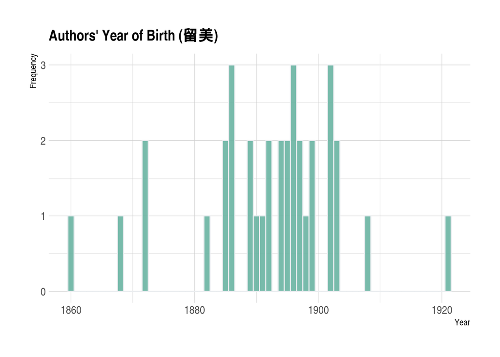

```r
library(hrbrthemes)
library(viridis)

liumei_authors_to_analyze %>% drop_na(BirthYear) %>%
  mutate(BirthYear = as.numeric(BirthYear))%>%
  ggplot( aes(x=BirthYear)) +
  geom_histogram( binwidth=1, fill="#69b3a2", color="#e9ecef", alpha=0.9) +
  ggtitle("Bin size = 1") +
  theme_ipsum() +
  theme(
    plot.title = element_text(size=15)
  ) +
  labs(title = "Authors' Year of Birth (留美)",
       x = "Year",
       y = "Frequency")
```

### Native Place

```r
liumei_authors_to_analyze %>% group_by(Birthplace) %>% count(sort = TRUE)
```

| Birthplace | n |
| --- | --- |
| NA | 17 |
| 浙江 | 8 |
| 江蘇 | 7 |
| 江西 | 3 |
| 河北 | 3 |
| UK | 2 |
| 安徽 | 2 |
| 廣東 | 2 |
| 湖北 | 2 |
| 湖南 | 2 |

[output cut: 5 more lines]

### Country of education

```r
liumei_authors_to_analyze %>% group_by('Country of Education') %>% count(sort = TRUE)
```

| "Country of Education" | n |
| --- | --- |
| Country of Education | 53 |

```r
liumei_authors_to_analyze %>% group_by('Education Country') %>% count(sort = TRUE)
```

| "Education Country" | n |
| --- | --- |
| Education Country | 53 |

### Professional background

```r
liumei_authors_to_analyze %>% group_by(Occupation) %>% count(sort = TRUE)
```

| Occupation | n |
| --- | --- |
| scholar | 21 |
| NA | 11 |
| scholar-official | 9 |
| professional writer | 5 |
| other | 4 |
| official-bureaucrat | 3 |

```r
liumei_authors_to_analyze %>% group_by(Occupation2) %>% count(sort = TRUE)
```

| Occupation2 | n |
| --- | --- |
| social sciences | 16 |
| humanities | 12 |
| NA | 11 |
| engineer | 2 |
| journalist | 2 |
| natural sciences | 2 |
| translator | 2 |
| architect | 1 |
| banking | 1 |
| local magistrate | 1 |

[output cut: 3 more lines]

```r
liumei_authors_to_analyze %>% group_by(Specialization) %>% count(sort = TRUE)
```

| Specialization | n |
| --- | --- |
| NA | 13 |
| politician | 2 |
| architect | 1 |
| botanist, educator, cultural scholar | 1 |
| chemist, politician | 1 |
| economist, bureaucrat | 1 |
| economist? | 1 |
| educator and writer | 1 |
| educator, philosopher, theologist, YMCA leader | 1 |
| educator, publisher | 1 |

[output cut: 30 more lines]

### Political Affiliation

```r
liumei_authors_to_analyze %>% group_by(Party) %>% count(sort = TRUE)
```

| Party | n |
| --- | --- |
| NA | 47 |
| GMD | 3 |
| DL | 1 |
| GMD-DL | 1 |
| TMH-GMD | 1 |

**Note**: DL = Democratic League. GMD = Guomindang. TMH = Tongmenghui.

# Multiple Correspondance Analysis (MCA)

## Data Preparation

```r
liumei_mca <- liumei_authors_to_analyze %>%
  filter(Nationality == "Chinese") %>%
  select(Name, Generation, 'Education Country', Occupation, Sentiment, Topic)

liumei_mca <-  liumei_mca %>% drop_na(Generation) # 34 remain
liumei_mca <- column_to_rownames(liumei_mca, "Name")
```

```r
liumei_mca
```

|  | Generation | Education Country | Occupation | Sentiment | Topic |
| --- | --- | --- | --- | --- | --- |
| 周由廑 | Pre1895 | China-NA | scholar | Positive | T5. Regulation/Organization |
| 姚大榮 | Pre1895 | China-NA | scholar-official | Negative | T2. International Treaties |
| 潘公展 | Post1895 | China-NA | official-bureaucrat | Negative | T3. Society/Culture |
| 王汝鼎 | Pre1895 | China-NA | scholar-official | Negative | T5. Regulation/Organization |
| 祁森煥 | Post1895 | China-NA | professional writer | Positive | T2. International Treaties |
| 許君遠 | Post1895 | China-NA | professional writer | Positive | T3. Society/Culture |
| 陳嘉異 | Pre1895 | China-NA | scholar | Positive | T2. International Treaties |
| 陸費執 | Pre1895 | China-NA | professional writer | Positive | T5. Regulation/Organization |
| 樓桐孫 | Post1895 | Europe | scholar | Positive | T1. East/West |
| 郭一岑 | Pre1895 | Europe | scholar | Positive | T5. Regulation/Organization |

[output cut: 24 more lines]

## MCA

```r
library(FactoMineR)
res.MCA<-MCA(liumei_mca,graph=FALSE)
```

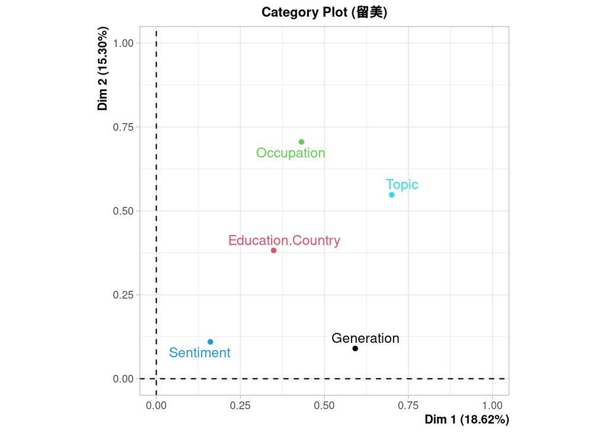

```r
# Plot 2 first dimensions

plot.MCA(res.MCA, choix='var',title="Category Plot (留美)",col.var=c(1,2,3,4,5))
```

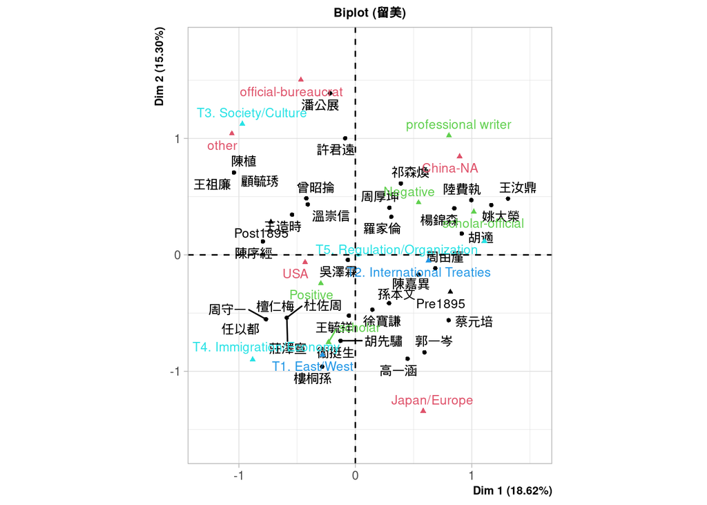

```r
plot.MCA(res.MCA,col.var=c(1,1,2,2,2,2,2,3,3,3,3,3,4,4,5,5,5,5,5),title="Biplot (留美)", cex=0.8,cex.main=0.8,cex.axis=0.8, autoLab = "yes",label =c('ind','var'))
```

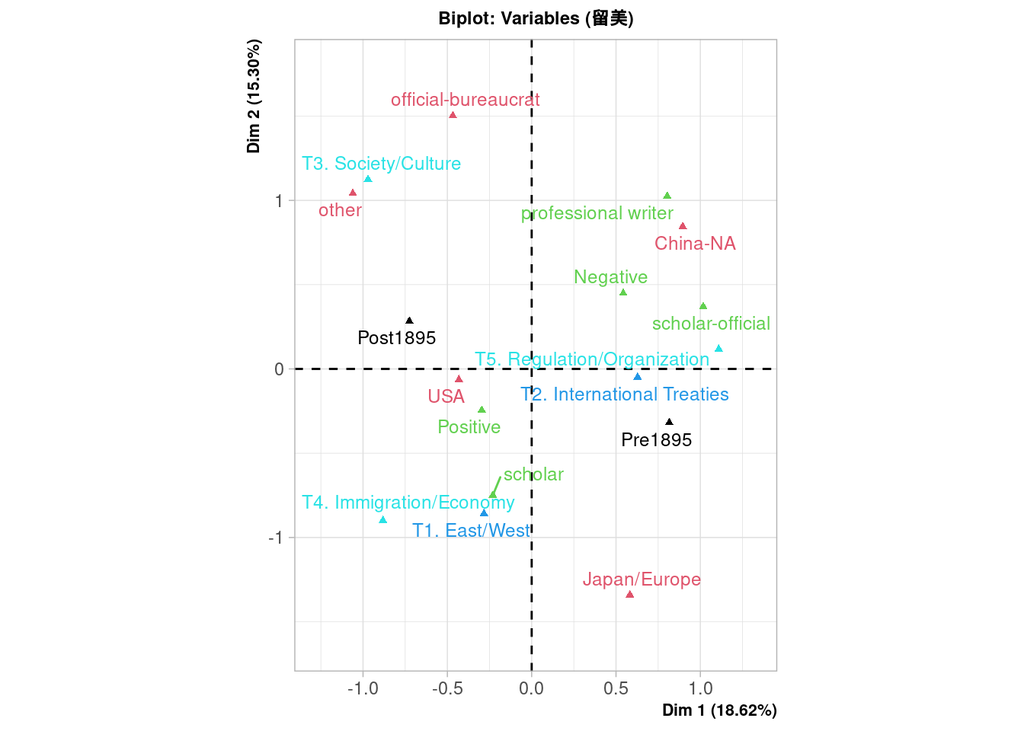

```r
plot.MCA(res.MCA,col.var=c(1,1,2,2,2,2,2,3,3,3,3,3,4,4,5,5,5,5,5),title="Biplot: Variables (留美)", invisible= 'ind', cex=0.8,cex.main=0.8,cex.axis=0.8, autoLab = "yes",label =c('var'))
```

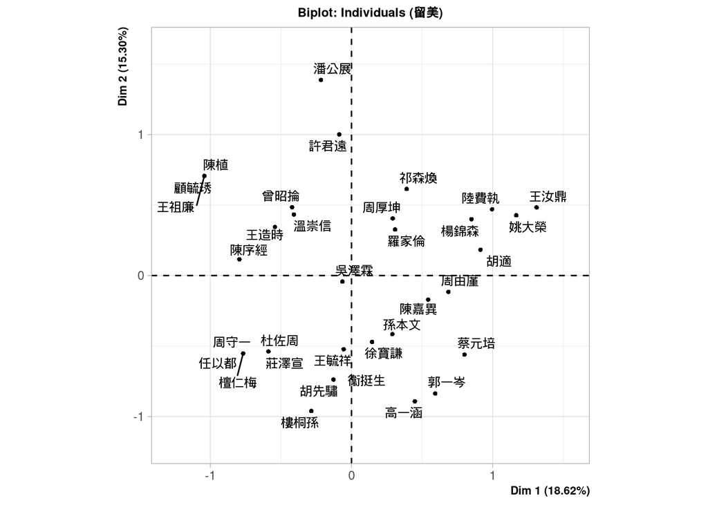

```r
plot.MCA(res.MCA,col.var=c(1,1,2,2,2,2,2,3,3,3,3,3,4,4,5,5,5,5,5),title="Biplot: Individuals (留美)", invisible= 'var', cex=0.8,cex.main=0.8,cex.axis=0.8, autoLab = "yes",label =c('ind'))
```

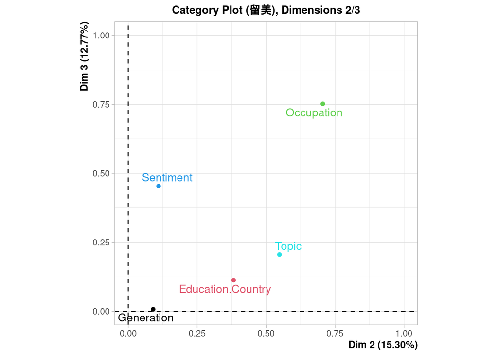

```r
# Add 3rd dimension

plot.MCA(res.MCA, choix='var',title="Category Plot (留美), Dimensions 2/3",axes=c(2,3),col.var=c(1,2,3,4,5))
```

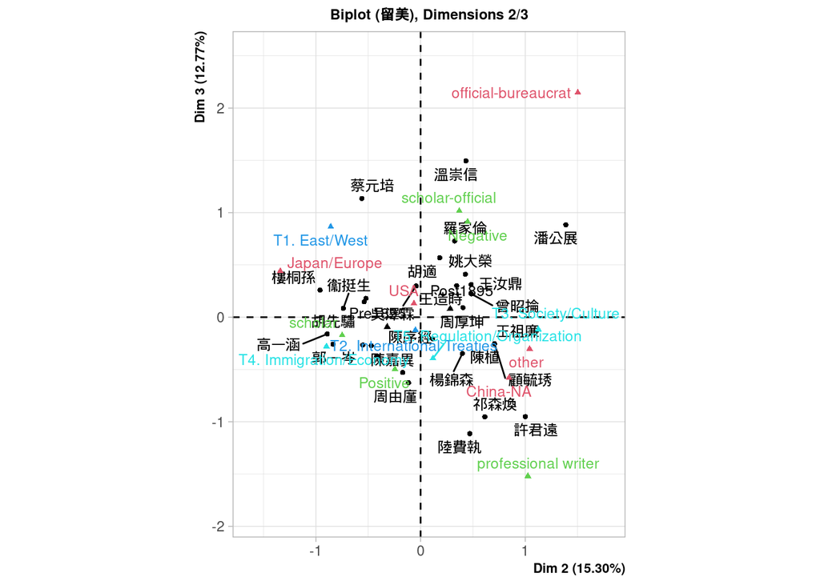

```r
plot.MCA(res.MCA,axes=c(2,3),col.var=c(1,1,2,2,2,2,2,3,3,3,3,3,4,4,5,5,5,5,5),title="Biplot (留美), Dimensions 2/3", autoLab = "yes", cex=0.8,cex.main=0.8,cex.axis=0.8,label =c('ind','var'))
```

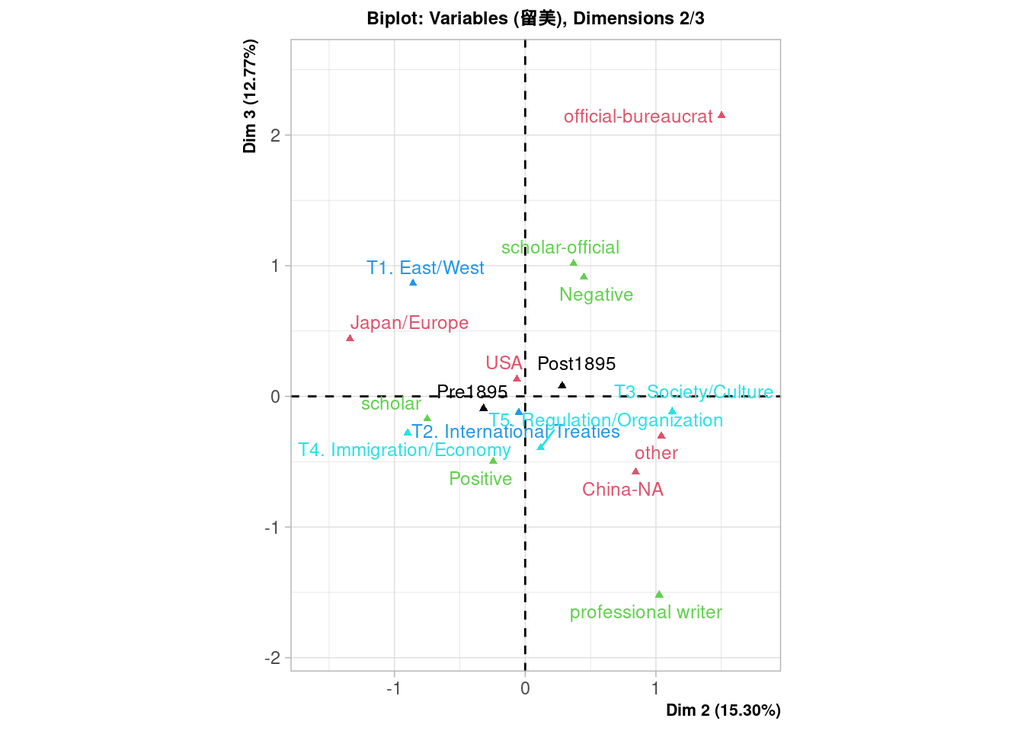

```r
plot.MCA(res.MCA,axes=c(2,3),col.var=c(1,1,2,2,2,2,2,3,3,3,3,3,4,4,5,5,5,5,5),title="Biplot: Variables (留美), Dimensions 2/3", invisible= 'ind', autoLab = "yes", cex=0.8,cex.main=0.8,cex.axis=0.8,label =c('var'))
```

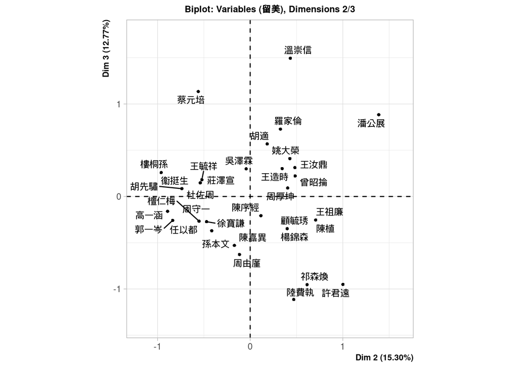

```r
plot.MCA(res.MCA,axes=c(2,3),col.var=c(1,1,2,2,2,2,2,3,3,3,3,3,4,4,5,5,5,5,5),title="Biplot: Variables (留美), Dimensions 2/3", invisible= 'var', autoLab = "yes", cex=0.8,cex.main=0.8,cex.axis=0.8,label =c('ind'))
```

```r
# Statistics

dimdesc(res.MCA)
```

```
## $`Dim 1`
##
## Link between the variable and the categorical variable (1-way anova)
## =============================================
##                          R2      p.value
## Generation        0.5918376 1.058704e-07
## Topic             0.7002421 2.887926e-07
## Education.Country 0.3492185 1.283056e-03
## Occupation        0.4318505 1.998733e-03
## Sentiment         0.1607814 1.876354e-02
##
## Link between variable and the categories of the categorical variables
## ================================================================
##                                     Estimate      p.value
## Generation=Pre1895                 0.5151144 1.058704e-07
## Topic=T5. Regulation/Organization  0.7945787 1.077276e-04
## Education.Country=China-NA         0.3654297 2.801661e-03
## Occupation=scholar-official        0.6716172 4.936421e-03
## Sentiment=Negative                 0.2804236 1.876354e-02
## Occupation=other                  -0.7172533 2.366305e-02
## Sentiment=Positive                -0.2804236 1.876354e-02
## Topic=T3. Society/Culture         -0.5955265 1.022774e-03
## Education.Country=USA             -0.5217103 2.842826e-04
## Generation=Post1895               -0.5151144 1.058704e-07
##
## $`Dim 2`
##
## Link between the variable and the categorical variable (1-way anova)
## =============================================
##                          R2      p.value
## Occupation        0.7055525 2.243954e-07
## Topic             0.5483233 8.848269e-05
## Education.Country 0.3821583 5.735841e-04
##
## Link between variable and the categories of the categorical variables
## ================================================================
##                                  Estimate      p.value
## Topic=T3. Society/Culture       0.7500199 8.015290e-05
## Education.Country=China-NA      0.6251503 5.156057e-03
## Occupation=other                0.2446606 2.648915e-02
```

[output cut: 8 more lines]

```
## Link between the variable and the categorical variable (1-way anova)
## =============================================
##                   R2      p.value
## Occupation 0.7521306 1.958818e-08
## Sentiment  0.4537824 1.262209e-05
##
## Link between variable and the categories of the categorical variables
## ================================================================
##                                  Estimate      p.value
## Sentiment=Negative              0.3901873 1.262209e-05
## Occupation=official-bureaucrat  1.0598608 1.055228e-03
## Occupation=scholar-official     0.4332867 4.969405e-03
## Topic=T1. East/West             0.4841439 9.125685e-03
## Occupation=professional writer -0.9707434 6.605967e-04
## Sentiment=Positive             -0.3901873 1.262209e-05
```